# Video Game Sales Analysis Project

## Project Overview

In this project, you'll analyze video game sales data to identify patterns that determine a game's success. Working as an analyst for the online store Ice, you'll use this information to help plan future advertising campaigns.

## Introduction

The purpose of this project is to analyze video game sales data to forecast the features which make up a video game's success. By identifying patterns and trends across different platforms, genres and regions we aim to gather insights to help make future decisions regarding video game releases.

## Environment Setup and Required Libraries

```python
# Import all required libraries
import pandas as pd
import numpy as np
import matplotlib.pyplot as plt
import seaborn as sns
from scipy import stats as st
```

## Step 1: Loading and Initial Data Exploration

First, let's load our dataset and examine its basic properties:

```python
# Load the dataset
df = pd.read_csv('/datasets/games.csv')
```

```python
# Display basic information about the dataset
display(df.info())
display(df.head())
```

```
<class 'pandas.core.frame.DataFrame'>
RangeIndex: 16715 entries, 0 to 16714
Data columns (total 11 columns):
 #   Column           Non-Null Count  Dtype
---  ------           --------------  -----
 0   Name             16713 non-null  object
 1   Platform         16715 non-null  object
 2   Year_of_Release  16446 non-null  float64
 3   Genre            16713 non-null  object
 4   NA_sales         16715 non-null  float64
 5   EU_sales         16715 non-null  float64
 6   JP_sales         16715 non-null  float64
 7   Other_sales      16715 non-null  float64
 8   Critic_Score     8137 non-null   float64
 9   User_Score       10014 non-null  object
 10  Rating           9949 non-null   object
dtypes: float64(6), object(5)
memory usage: 1.4+ MB
```

```
None
```

|  | Name | Platform | Year_of_Release | Genre | NA_sales | EU_sales | JP_sales | Other_sales | Critic_Score | User_Score | Rating |
| --- | --- | --- | --- | --- | --- | --- | --- | --- | --- | --- | --- |
| 0 | Wii Sports | Wii | 2006.0 | Sports | 41.36 | 28.96 | 3.77 | 8.45 | 76.0 | 8 | E |
| 1 | Super Mario Bros. | NES | 1985.0 | Platform | 29.08 | 3.58 | 6.81 | 0.77 | NaN | NaN | NaN |
| 2 | Mario Kart Wii | Wii | 2008.0 | Racing | 15.68 | 12.76 | 3.79 | 3.29 | 82.0 | 8.3 | E |
| 3 | Wii Sports Resort | Wii | 2009.0 | Sports | 15.61 | 10.93 | 3.28 | 2.95 | 80.0 | 8 | E |
| 4 | Pokemon Red/Pokemon Blue | GB | 1996.0 | Role-Playing | 11.27 | 8.89 | 10.22 | 1.00 | NaN | NaN | NaN |

```python
# Check for duplicate rows
duplicate_rows = df[df.duplicated()]
print(f'Total duplicate rows: {len(duplicate_rows)}')

# Check for duplicate entries
duplicate_games = df[df.duplicated(subset=['Name', 'Platform', 'Year_of_Release'])]
display(duplicate_games)
nfl = df[df['Name'] == 'Madden NFL 13']
print(nfl)
display(df[df['Name'].isna()])
```

```
Total duplicate rows: 0
```

|  | Name | Platform | Year_of_Release | Genre | NA_sales | EU_sales | JP_sales | Other_sales | Critic_Score | User_Score | Rating |
| --- | --- | --- | --- | --- | --- | --- | --- | --- | --- | --- | --- |
| 14244 | NaN | GEN | 1993.0 | NaN | 0.0 | 0.00 | 0.03 | 0.0 | NaN | NaN | NaN |
| 16230 | Madden NFL 13 | PS3 | 2012.0 | Sports | 0.0 | 0.01 | 0.00 | 0.0 | 83.0 | 5.5 | E |

```
                Name Platform  Year_of_Release   Genre  NA_sales  EU_sales  \
507    Madden NFL 13     X360           2012.0  Sports      2.53      0.15
604    Madden NFL 13      PS3           2012.0  Sports      2.11      0.22
3986   Madden NFL 13      Wii           2012.0  Sports      0.47      0.00
5887   Madden NFL 13      PSV           2012.0  Sports      0.28      0.00
7066   Madden NFL 13     WiiU           2012.0  Sports      0.21      0.00
16230  Madden NFL 13      PS3           2012.0  Sports      0.00      0.01

       JP_sales  Other_sales  Critic_Score User_Score Rating
507         0.0         0.17          81.0        5.8      E
604         0.0         0.23          83.0        5.5      E
3986        0.0         0.03           NaN        7.3      E
5887        0.0         0.02          63.0        7.3      E
7066        0.0         0.02          75.0        6.7      E
16230       0.0         0.00          83.0        5.5      E
```

|  | Name | Platform | Year_of_Release | Genre | NA_sales | EU_sales | JP_sales | Other_sales | Critic_Score | User_Score | Rating |
| --- | --- | --- | --- | --- | --- | --- | --- | --- | --- | --- | --- |
| 659 | NaN | GEN | 1993.0 | NaN | 1.78 | 0.53 | 0.00 | 0.08 | NaN | NaN | NaN |
| 14244 | NaN | GEN | 1993.0 | NaN | 0.00 | 0.00 | 0.03 | 0.00 | NaN | NaN | NaN |

We identified two duplicate entries with the same 'name', 'platform', and 'year_of_release'. The second occurrence of Madden NFL 13 on PS3 appears to be a mistake, as one row contains more complete and inclusive data. Additionally, we found other duplicate rows where the 'name' field is missing, making it impossible to verify the game's identity. To ensure data integrity we will remove the duplicate entries.

```python
#drop duplicates
df = df.drop_duplicates(subset=['Name', 'Platform', 'Year_of_Release'])
df = df.reset_index(drop=True)
duplicates = df[df.duplicated(subset=['Name', 'Platform', 'Year_of_Release'])]
print(f'Updated total of duplicate entries: {len(duplicates)}')
```

```
Updated total of duplicate entries: 0
```

### Key Questions to Answer:

- What's the total number of records in our dataset?
- What data types are present in each column?
- Are there any obvious issues with the data?
- Do we see any immediate patterns or anomalies?

## Step 2: Data Preparation

### 2.1 Standardizing Column Names

```python
# Convert column names to lowercase
df.columns = df.columns.str.lower()
```

```python
# Verify the changes
df.columns
```

```
Index(['name', 'platform', 'year_of_release', 'genre', 'na_sales', 'eu_sales',
       'jp_sales', 'other_sales', 'critic_score', 'user_score', 'rating'],
      dtype='object')
```

### 2.2 Data Type Conversion

```python
# Check current data types
df.info()
```

```
<class 'pandas.core.frame.DataFrame'>
RangeIndex: 16713 entries, 0 to 16712
Data columns (total 11 columns):
 #   Column           Non-Null Count  Dtype
---  ------           --------------  -----
 0   name             16712 non-null  object
 1   platform         16713 non-null  object
 2   year_of_release  16444 non-null  float64
 3   genre            16712 non-null  object
 4   na_sales         16713 non-null  float64
 5   eu_sales         16713 non-null  float64
 6   jp_sales         16713 non-null  float64
 7   other_sales      16713 non-null  float64
 8   critic_score     8136 non-null   float64
 9   user_score       10013 non-null  object
 10  rating           9948 non-null   object
dtypes: float64(6), object(5)
memory usage: 1.4+ MB
```

```python
# Make changes to data types if necessary
# Describe the columns where the data types have been changed and why.
df['year_of_release'] = df['year_of_release'].astype('Int64')
df.info()
```

```
<class 'pandas.core.frame.DataFrame'>
RangeIndex: 16713 entries, 0 to 16712
Data columns (total 11 columns):
 #   Column           Non-Null Count  Dtype
---  ------           --------------  -----
 0   name             16712 non-null  object
 1   platform         16713 non-null  object
 2   year_of_release  16444 non-null  Int64
 3   genre            16712 non-null  object
 4   na_sales         16713 non-null  float64
 5   eu_sales         16713 non-null  float64
 6   jp_sales         16713 non-null  float64
 7   other_sales      16713 non-null  float64
 8   critic_score     8136 non-null   float64
 9   user_score       10013 non-null  object
 10  rating           9948 non-null   object
dtypes: Int64(1), float64(5), object(5)
memory usage: 1.4+ MB
```

```python
# Pay attention to the abbreviation TBD (to be determined). Specify how you intend to handle such cases.
df['user_score'] = pd.to_numeric(df['user_score'], errors='coerce')
df.info()
```

```
<class 'pandas.core.frame.DataFrame'>
RangeIndex: 16713 entries, 0 to 16712
Data columns (total 11 columns):
 #   Column           Non-Null Count  Dtype
---  ------           --------------  -----
 0   name             16712 non-null  object
 1   platform         16713 non-null  object
 2   year_of_release  16444 non-null  Int64
 3   genre            16712 non-null  object
 4   na_sales         16713 non-null  float64
 5   eu_sales         16713 non-null  float64
 6   jp_sales         16713 non-null  float64
 7   other_sales      16713 non-null  float64
 8   critic_score     8136 non-null   float64
 9   user_score       7589 non-null   float64
 10  rating           9948 non-null   object
dtypes: Int64(1), float64(6), object(4)
memory usage: 1.4+ MB
```

We type cast 'user_score' to float64 to facilitate numerical operations and comparisons with other quantitative columns. More than likely there are entries of 'tbd' due to games not having been rated yet. By coercing errors in the type casting call we can deal with these 'tbd' values in the future by leaving them as NaNs for now while analyzing regarding user scores. We also converted 'year_of_release' to type int64 in order to perform statistical analysis for this feature.

### 2.3 Handling Missing Values

```python
# Examine missing values
missing_values = df.isna().sum()
print(missing_values)
```

```
name                  1
platform              0
year_of_release     269
genre                 1
na_sales              0
eu_sales              0
jp_sales              0
other_sales           0
critic_score       8577
user_score         9124
rating             6765
dtype: int64
```

```python
# Calculate percentage of missing values
missing_percent = df.isna().mean() * 100
print(missing_percent)
```

```
name                0.005983
platform            0.000000
year_of_release     1.609526
genre               0.005983
na_sales            0.000000
eu_sales            0.000000
jp_sales            0.000000
other_sales         0.000000
critic_score       51.319332
user_score         54.592234
rating             40.477473
dtype: float64
```

```python
# Analyze patterns in missing values
df['missing_year'] = df['year_of_release'].isna().astype(int)
df['missing_critic'] = df['critic_score'].isna().astype(int)
df['missing_user'] = df['user_score'].isna().astype(int)
df['missing_rating'] = df['rating'].isna().astype(int)

#compare differences between games with and without the year of release
correlations_y = df.corr()['missing_year'].sort_values(ascending=False)
print('Missing Year\n', correlations_y, '\n')

#compare differences between games with and without critic reviews
correlations_c = df.corr()['missing_critic'].sort_values(ascending=False)
print('Missing Critic Review\n', correlations_c, '\n')

#compare differences between games with and without user reviews
correlations_u = df.corr()['missing_user'].sort_values(ascending=False)
print('Missing User Review\n', correlations_u, '\n')

#compare differences between games with and without an ESRB rating.
correlations_r = df.corr()['missing_rating'].sort_values(ascending=False)
print('Missing ESRB Rating\n', correlations_r)
```

```
Missing Year
 missing_year       1.000000
missing_user      -0.004635
user_score        -0.006580
na_sales          -0.006841
other_sales       -0.010507
eu_sales          -0.013759
critic_score      -0.013769
missing_rating    -0.020230
jp_sales          -0.021830
missing_critic    -0.021926
year_of_release         NaN
Name: missing_year, dtype: float64

Missing Critic Review
 missing_critic     1.000000
missing_user       0.798632
missing_rating     0.782921
jp_sales           0.071235
missing_year      -0.021926
na_sales          -0.107274
year_of_release   -0.116868
eu_sales          -0.122403
other_sales       -0.130892
user_score        -0.133931
critic_score            NaN
Name: missing_critic, dtype: float64

Missing User Review
 missing_user       1.000000
missing_critic     0.798632
missing_rating     0.731027
jp_sales           0.054700
missing_year      -0.004635
na_sales          -0.126055
eu_sales          -0.144670
other_sales       -0.156538
year_of_release   -0.186319
critic_score      -0.230230
user_score              NaN
Name: missing_user, dtype: float64

Missing ESRB Rating
 missing_rating     1.000000
missing_critic     0.782921
missing_user       0.731027
jp_sales           0.125031
critic_score      -0.002560
user_score        -0.011431
missing_year      -0.020230
na_sales          -0.080829
eu_sales          -0.089026
other_sales       -0.110468
year_of_release   -0.225614
Name: missing_rating, dtype: float64
```

We can see high correlations between games that have a missing rating, critic or user review. For a majority of games missing one of these values they will also be missing values in the other two variables listed. The most significant correlation we see is that games missing a critic rating are also missing a user review. We do not see high correlations between missing 'year_of_release' games and other variables (besides a very minuscule negative correlation). Otherwise, games with missing data do have a negative impact on ratings and sales, besides in Japan: it seems in Japan there is a slight increase in sales with these missing scores and ratings.

```python
# Handle missing values based on analysis
# Your code here to handle missing values according to your strategy
df = df.dropna(subset=['name'])
missing_values_new = df.isna().sum()
print(missing_values_new)
df['has_all_reviews'] = df[['year_of_release', 'user_score', 'critic_score', 'rating']].notna().all(axis=1)
df.head()
```

```
name                  0
platform              0
year_of_release     269
genre                 0
na_sales              0
eu_sales              0
jp_sales              0
other_sales           0
critic_score       8576
user_score         9123
rating             6764
missing_year          0
missing_critic        0
missing_user          0
missing_rating        0
dtype: int64
```

|  | name | platform | year_of_release | genre | na_sales | eu_sales | jp_sales | other_sales | critic_score | user_score | rating | missing_year | missing_critic | missing_user | missing_rating | has_all_reviews |
| --- | --- | --- | --- | --- | --- | --- | --- | --- | --- | --- | --- | --- | --- | --- | --- | --- |
| 0 | Wii Sports | Wii | 2006 | Sports | 41.36 | 28.96 | 3.77 | 8.45 | 76.0 | 8.0 | E | 0 | 0 | 0 | 0 | True |
| 1 | Super Mario Bros. | NES | 1985 | Platform | 29.08 | 3.58 | 6.81 | 0.77 | NaN | NaN | NaN | 0 | 1 | 1 | 1 | False |
| 2 | Mario Kart Wii | Wii | 2008 | Racing | 15.68 | 12.76 | 3.79 | 3.29 | 82.0 | 8.3 | E | 0 | 0 | 0 | 0 | True |
| 3 | Wii Sports Resort | Wii | 2009 | Sports | 15.61 | 10.93 | 3.28 | 2.95 | 80.0 | 8.0 | E | 0 | 0 | 0 | 0 | True |
| 4 | Pokemon Red/Pokemon Blue | GB | 1996 | Role-Playing | 11.27 | 8.89 | 10.22 | 1.00 | NaN | NaN | NaN | 0 | 1 | 1 | 1 | False |

```python
# Why do you think the values are missing? Give possible reasons.
# Explain why you filled in the missing values as you did or why you decided to leave them blank.
```

The 'year_of_release' column could be missing data due to older games lacking proper documentation or new games yet to release. Most likely, some games have not been rated yet and that is why they are missing values. Whether a game has ratings or not could be due to a game's popularity and success. Once again, we are incapable of identifying the game with the missing name so we will drop this row. About half of all data is missing 'critic_score', 'user_score' and 'rating'. Since this is a high proportion of the data we should not just drop the rows. Instead, we will create new features that describes whether each row has all ratings or the 'year_of_release' so that way we can build new dataframes in order to analyze the data within these columns.

### 2.4 Calculate Total Sales

```python
# Calculate total sales across all regions and put them in a different column
df['total_sales'] = df['na_sales'] + df['eu_sales'] + df['jp_sales'] + df['other_sales']
df.head()
```

|  | name | platform | year_of_release | genre | na_sales | eu_sales | jp_sales | other_sales | critic_score | user_score | rating | missing_year | missing_critic | missing_user | missing_rating | has_all_reviews | total_sales |
| --- | --- | --- | --- | --- | --- | --- | --- | --- | --- | --- | --- | --- | --- | --- | --- | --- | --- |
| 0 | Wii Sports | Wii | 2006 | Sports | 41.36 | 28.96 | 3.77 | 8.45 | 76.0 | 8.0 | E | 0 | 0 | 0 | 0 | True | 82.54 |
| 1 | Super Mario Bros. | NES | 1985 | Platform | 29.08 | 3.58 | 6.81 | 0.77 | NaN | NaN | NaN | 0 | 1 | 1 | 1 | False | 40.24 |
| 2 | Mario Kart Wii | Wii | 2008 | Racing | 15.68 | 12.76 | 3.79 | 3.29 | 82.0 | 8.3 | E | 0 | 0 | 0 | 0 | True | 35.52 |
| 3 | Wii Sports Resort | Wii | 2009 | Sports | 15.61 | 10.93 | 3.28 | 2.95 | 80.0 | 8.0 | E | 0 | 0 | 0 | 0 | True | 32.77 |
| 4 | Pokemon Red/Pokemon Blue | GB | 1996 | Role-Playing | 11.27 | 8.89 | 10.22 | 1.00 | NaN | NaN | NaN | 0 | 1 | 1 | 1 | False | 31.38 |

# Step 3: Analyzing Video Game Sales Data

## 3.1 Temporal Analysis of Game Releases

Let's first examine the distribution of game releases across different years to understand our data's coverage and significance:

```python
# Create a DataFrame with game releases by year
by_year = df[df['year_of_release'].notna()]
by_year = by_year.groupby('year_of_release')['name'].count().reset_index()
by_year.columns = ['year_of_release', 'num_releases']
by_year.info()
```

```
<class 'pandas.core.frame.DataFrame'>
RangeIndex: 37 entries, 0 to 36
Data columns (total 2 columns):
 #   Column           Non-Null Count  Dtype
---  ------           --------------  -----
 0   year_of_release  37 non-null     int64
 1   num_releases     37 non-null     int64
dtypes: int64(2)
memory usage: 720.0 bytes
```

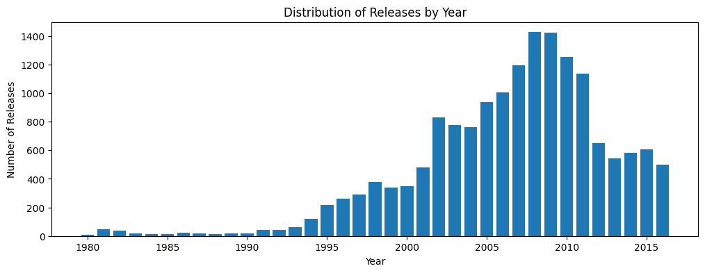

```python
# Visualize the distribution of games across years
plt.figure(figsize=(12,4))
plt.bar(by_year['year_of_release'], by_year['num_releases'])
plt.xlabel('Year')
plt.title('Distribution of Releases by Year')
plt.ylabel('Number of Releases')
plt.show()
```

```python
# Display summary statistics for each year
by_year.groupby('year_of_release').describe().round(2)
```

| year_of_release | num_releases count | num_releases mean | num_releases std | num_releases min | num_releases 25% | num_releases 50% | num_releases 75% | num_releases max |
| --- | --- | --- | --- | --- | --- | --- | --- | --- |
| 1980 | 1.0 | 9.0 | NaN | 9.0 | 9.0 | 9.0 | 9.0 | 9.0 |
| 1981 | 1.0 | 46.0 | NaN | 46.0 | 46.0 | 46.0 | 46.0 | 46.0 |
| 1982 | 1.0 | 36.0 | NaN | 36.0 | 36.0 | 36.0 | 36.0 | 36.0 |
| 1983 | 1.0 | 17.0 | NaN | 17.0 | 17.0 | 17.0 | 17.0 | 17.0 |
| 1984 | 1.0 | 14.0 | NaN | 14.0 | 14.0 | 14.0 | 14.0 | 14.0 |
| 1985 | 1.0 | 14.0 | NaN | 14.0 | 14.0 | 14.0 | 14.0 | 14.0 |
| 1986 | 1.0 | 21.0 | NaN | 21.0 | 21.0 | 21.0 | 21.0 | 21.0 |
| 1987 | 1.0 | 16.0 | NaN | 16.0 | 16.0 | 16.0 | 16.0 | 16.0 |
| 1988 | 1.0 | 15.0 | NaN | 15.0 | 15.0 | 15.0 | 15.0 | 15.0 |
| 1989 | 1.0 | 17.0 | NaN | 17.0 | 17.0 | 17.0 | 17.0 | 17.0 |
| 1990 | 1.0 | 16.0 | NaN | 16.0 | 16.0 | 16.0 | 16.0 | 16.0 |
| 1991 | 1.0 | 41.0 | NaN | 41.0 | 41.0 | 41.0 | 41.0 | 41.0 |
| 1992 | 1.0 | 43.0 | NaN | 43.0 | 43.0 | 43.0 | 43.0 | 43.0 |
| 1993 | 1.0 | 60.0 | NaN | 60.0 | 60.0 | 60.0 | 60.0 | 60.0 |
| 1994 | 1.0 | 121.0 | NaN | 121.0 | 121.0 | 121.0 | 121.0 | 121.0 |
| 1995 | 1.0 | 219.0 | NaN | 219.0 | 219.0 | 219.0 | 219.0 | 219.0 |
| 1996 | 1.0 | 263.0 | NaN | 263.0 | 263.0 | 263.0 | 263.0 | 263.0 |
| 1997 | 1.0 | 289.0 | NaN | 289.0 | 289.0 | 289.0 | 289.0 | 289.0 |
| 1998 | 1.0 | 379.0 | NaN | 379.0 | 379.0 | 379.0 | 379.0 | 379.0 |
| 1999 | 1.0 | 338.0 | NaN | 338.0 | 338.0 | 338.0 | 338.0 | 338.0 |
| 2000 | 1.0 | 350.0 | NaN | 350.0 | 350.0 | 350.0 | 350.0 | 350.0 |
| 2001 | 1.0 | 482.0 | NaN | 482.0 | 482.0 | 482.0 | 482.0 | 482.0 |
| 2002 | 1.0 | 829.0 | NaN | 829.0 | 829.0 | 829.0 | 829.0 | 829.0 |
| 2003 | 1.0 | 775.0 | NaN | 775.0 | 775.0 | 775.0 | 775.0 | 775.0 |
| 2004 | 1.0 | 762.0 | NaN | 762.0 | 762.0 | 762.0 | 762.0 | 762.0 |
| 2005 | 1.0 | 939.0 | NaN | 939.0 | 939.0 | 939.0 | 939.0 | 939.0 |
| 2006 | 1.0 | 1006.0 | NaN | 1006.0 | 1006.0 | 1006.0 | 1006.0 | 1006.0 |
| 2007 | 1.0 | 1197.0 | NaN | 1197.0 | 1197.0 | 1197.0 | 1197.0 | 1197.0 |
| 2008 | 1.0 | 1427.0 | NaN | 1427.0 | 1427.0 | 1427.0 | 1427.0 | 1427.0 |
| 2009 | 1.0 | 1426.0 | NaN | 1426.0 | 1426.0 | 1426.0 | 1426.0 | 1426.0 |
| 2010 | 1.0 | 1255.0 | NaN | 1255.0 | 1255.0 | 1255.0 | 1255.0 | 1255.0 |
| 2011 | 1.0 | 1136.0 | NaN | 1136.0 | 1136.0 | 1136.0 | 1136.0 | 1136.0 |
| 2012 | 1.0 | 652.0 | NaN | 652.0 | 652.0 | 652.0 | 652.0 | 652.0 |
| 2013 | 1.0 | 544.0 | NaN | 544.0 | 544.0 | 544.0 | 544.0 | 544.0 |
| 2014 | 1.0 | 581.0 | NaN | 581.0 | 581.0 | 581.0 | 581.0 | 581.0 |
| 2015 | 1.0 | 606.0 | NaN | 606.0 | 606.0 | 606.0 | 606.0 | 606.0 |
| 2016 | 1.0 | 502.0 | NaN | 502.0 | 502.0 | 502.0 | 502.0 | 502.0 |

```python
platform_totals = df.groupby('platform')['total_sales'].sum().sort_values(ascending=False)
platform_totals
```

```
platform
PS2     1255.77
X360     971.42
PS3      939.64
Wii      907.51
DS       806.12
PS       730.86
GBA      317.85
PS4      314.14
PSP      294.05
PC       259.52
3DS      259.00
XB       257.74
GB       255.46
NES      251.05
N64      218.68
SNES     200.04
GC       198.93
XOne     159.32
2600      96.98
WiiU      82.19
PSV       54.07
SAT       33.59
GEN       28.35
DC        15.95
SCD        1.86
NG         1.44
WS         1.42
TG16       0.16
3DO        0.10
GG         0.04
PCFX       0.03
Name: total_sales, dtype: float64
```

### Questions to Consider:

- Which years show significant numbers of game releases?
- Are there any notable trends or patterns in the number of releases?
- Is there enough recent data to make predictions for 2017?

2008 and 2009 have the most significant number of game releases. Up until that point we can see total releases increasing up and decreasing afterwards. While most recent years such as 2016 have smaller amounts of releases than peak years, we still have a healthy amount of data in order to analyze the data and make predictions for 2017.

## 3.2 Platform Sales Analysis Over Time

Now let's analyze how sales vary across platforms and years:

```python
# Calculate total sales by platform and year

by_year_platform = df[df['year_of_release'].notna()]
by_year_platform = by_year_platform.groupby(['year_of_release', 'platform'])['total_sales'].sum().reset_index()
by_year_platform
```

|  | year_of_release | platform | total_sales |
| --- | --- | --- | --- |
| 0 | 1980 | 2600 | 11.38 |
| 1 | 1981 | 2600 | 35.68 |
| 2 | 1982 | 2600 | 28.88 |
| 3 | 1983 | 2600 | 5.84 |
| 4 | 1983 | NES | 10.96 |
| ... | ... | ... | ... |
| 233 | 2016 | PSV | 4.25 |
| 234 | 2016 | Wii | 0.18 |
| 235 | 2016 | WiiU | 4.60 |
| 236 | 2016 | X360 | 1.52 |
| 237 | 2016 | XOne | 26.15 |

238 rows × 3 columns

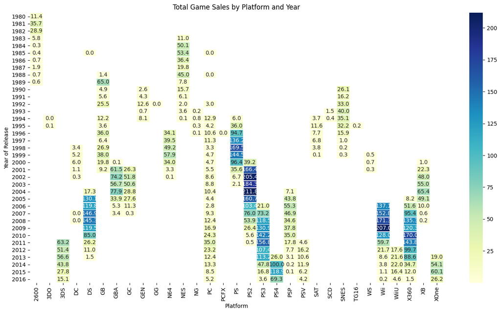

```python
# Create a heatmap of platform sales over time
heatmap_data = by_year_platform.pivot(index='year_of_release', columns='platform', values='total_sales')
plt.figure(figsize=(14, 8))
sns.heatmap(heatmap_data, cmap='YlGnBu', annot=True, fmt='.1f', linewidths=0.5)
plt.title('Total Game Sales by Platform and Year')
plt.xlabel('Platform')
plt.ylabel('Year of Release')
plt.tight_layout()
plt.show()
```

```python
# Identify platforms with declining sales
by_year_platform.describe()
```

|  | year_of_release | total_sales |
| --- | --- | --- |
| count | 238.000000 | 238.000000 |
| mean | 2002.474790 | 37.035126 |
| std | 9.030036 | 48.493731 |
| min | 1980.000000 | 0.020000 |
| 25% | 1996.000000 | 3.620000 |
| 50% | 2003.000000 | 16.055000 |
| 75% | 2010.000000 | 50.477500 |
| max | 2016.000000 | 211.810000 |

We see peaks in sales within the middle of our timeframe and can conclude that all platforms have declining sales if they still have any sales at all by 2016.

### Questions to Consider:

- Which platforms show consistent sales over time?
- Can you identify platforms that have disappeared from the market?
- What's the typical lifecycle of a gaming platform?

The DS, PS, PS2, PS3, PS4 and X360 show strong sales through the majority of the years that they were the latest generation console.

```python
platforms_before_2016 = set(by_year_platform[by_year_platform['year_of_release'] < 2016]['platform'].unique())
platforms_in_2016 = set(by_year_platform[by_year_platform['year_of_release'] == 2016]['platform'].unique())
vanished = platforms_before_2016 - platforms_in_2016
print('Vanished Platforms:', vanished)
```

```
Vanished Platforms: {'GG', 'PCFX', 'XB', 'TG16', 'SNES', 'DC', '3DO', 'SCD', 'PS2', 'WS', 'N64', 'PS', 'GC', 'PSP', 'GEN', 'NG', '2600', 'GBA', 'NES', 'SAT', 'DS', 'GB'}
```

```python
lifespans = df.groupby('platform')['year_of_release'].agg(['min', 'max'])
lifespans['lifespan'] = lifespans['max'] - lifespans['min'] + 1
average_lifespan = lifespans['lifespan'].mean()
print(f'Average Platform Lifecycle: {average_lifespan:.2f} years')
```

```
Average Platform Lifecycle: 8.61 years
```

## 3.3 Determining Relevant Time Period

Based on your analysis above, determine the appropriate time period for predicting 2017 sales:

```python
# Justify your choice with data
relevant_years = [2013, 2014, 2015, 2016]
df = df[df['year_of_release'].isin(relevant_years)]
df_time = df.groupby(['platform','year_of_release'])['total_sales'].sum().sort_values(ascending=False).reset_index()
df_time
```

|  | platform | year_of_release | total_sales |
| --- | --- | --- | --- |
| 0 | PS4 | 2015 | 118.90 |
| 1 | PS3 | 2013 | 113.25 |
| 2 | PS4 | 2014 | 100.00 |
| 3 | X360 | 2013 | 88.58 |
| 4 | PS4 | 2016 | 69.25 |
| 5 | XOne | 2015 | 60.14 |
| 6 | 3DS | 2013 | 56.57 |
| 7 | XOne | 2014 | 54.07 |
| 8 | PS3 | 2014 | 47.76 |
| 9 | 3DS | 2014 | 43.76 |
| 10 | X360 | 2014 | 34.74 |
| 11 | 3DS | 2015 | 27.78 |
| 12 | XOne | 2016 | 26.15 |
| 13 | PS4 | 2013 | 25.99 |
| 14 | WiiU | 2014 | 22.03 |
| 15 | WiiU | 2013 | 21.65 |
| 16 | XOne | 2013 | 18.96 |
| 17 | PS3 | 2015 | 16.82 |
| 18 | WiiU | 2015 | 16.35 |
| 19 | 3DS | 2016 | 15.14 |
| 20 | PC | 2014 | 13.28 |
| 21 | PC | 2013 | 12.38 |
| 22 | X360 | 2015 | 11.96 |
| 23 | PSV | 2014 | 11.90 |
| 24 | PSV | 2013 | 10.59 |
| 25 | Wii | 2013 | 8.59 |
| 26 | PC | 2015 | 8.52 |
| 27 | PSV | 2015 | 6.25 |
| 28 | PC | 2016 | 5.25 |
| 29 | WiiU | 2016 | 4.60 |
| 30 | PSV | 2016 | 4.25 |
| 31 | Wii | 2014 | 3.75 |
| 32 | PS3 | 2016 | 3.60 |
| 33 | PSP | 2013 | 3.14 |
| 34 | DS | 2013 | 1.54 |
| 35 | X360 | 2016 | 1.52 |
| 36 | Wii | 2015 | 1.14 |
| 37 | PSP | 2014 | 0.24 |
| 38 | Wii | 2016 | 0.18 |
| 39 | PSP | 2015 | 0.12 |

### Document Your Decision:

- What years did you select and why?
- How does this period reflect current market conditions?
- What factors influenced your decision?

2013-2016 is the best timeframe for analyzing the data because this period is continuous with 2017, because the majority of games that still have sales carry values across all of those years, and because the older years and systems are irrelevant to our hypothesis testing of current video game sales forecasting.

## 3.4 Platform Performance Analysis

Using your selected time period, let's analyze platform performance:

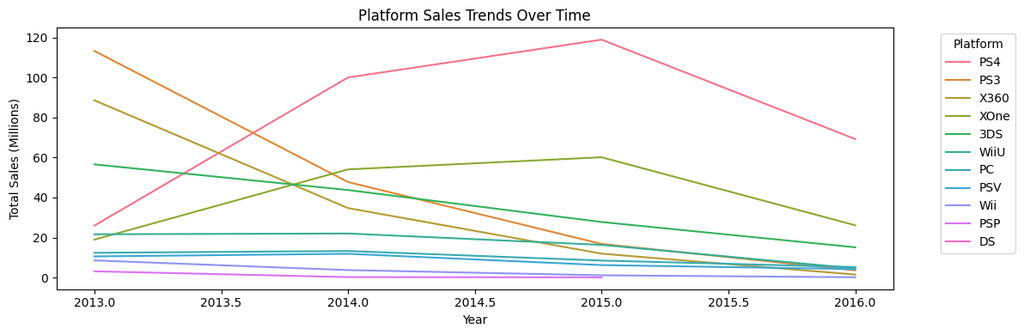

```python
# Analyze platform sales trends
plt.figure(figsize=(12, 4))
sns.lineplot(data=df_time, x='year_of_release', y='total_sales', hue='platform')
plt.title('Platform Sales Trends Over Time')
plt.xlabel('Year')
plt.ylabel('Total Sales (Millions)')
plt.legend(bbox_to_anchor=(1.05, 1), loc='upper left', title='Platform')
plt.tight_layout()
plt.show()
```

```python
# Sort platforms by total sales
total_sales_by_platform = df_time.groupby('platform')['total_sales'].sum().sort_values(ascending=False).reset_index()
total_sales_by_platform
```

|  | platform | total_sales |
| --- | --- | --- |
| 0 | PS4 | 314.14 |
| 1 | PS3 | 181.43 |
| 2 | XOne | 159.32 |
| 3 | 3DS | 143.25 |
| 4 | X360 | 136.80 |
| 5 | WiiU | 64.63 |
| 6 | PC | 39.43 |
| 7 | PSV | 32.99 |
| 8 | Wii | 13.66 |
| 9 | PSP | 3.50 |
| 10 | DS | 1.54 |

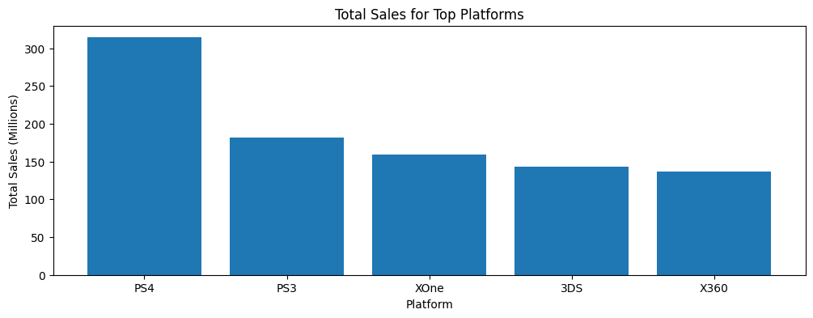

|  | platform | year_of_release | total_sales | yoy_growth |
| --- | --- | --- | --- | --- |
| 9 | 3DS | 2014 | 43.76 | -0.23 |
| 11 | 3DS | 2015 | 27.78 | -0.37 |
| 19 | 3DS | 2016 | 15.14 | -0.46 |
| 20 | PC | 2014 | 13.28 | 0.07 |
| 26 | PC | 2015 | 8.52 | -0.36 |
| 28 | PC | 2016 | 5.25 | -0.38 |
| 8 | PS3 | 2014 | 47.76 | -0.58 |
| 17 | PS3 | 2015 | 16.82 | -0.65 |
| 32 | PS3 | 2016 | 3.60 | -0.79 |
| 2 | PS4 | 2014 | 100.00 | 2.85 |
| 0 | PS4 | 2015 | 118.90 | 0.19 |
| 4 | PS4 | 2016 | 69.25 | -0.42 |
| 37 | PSP | 2014 | 0.24 | -0.92 |
| 39 | PSP | 2015 | 0.12 | -0.50 |
| 23 | PSV | 2014 | 11.90 | 0.12 |
| 27 | PSV | 2015 | 6.25 | -0.47 |
| 30 | PSV | 2016 | 4.25 | -0.32 |
| 31 | Wii | 2014 | 3.75 | -0.56 |
| 36 | Wii | 2015 | 1.14 | -0.70 |
| 38 | Wii | 2016 | 0.18 | -0.84 |
| 14 | WiiU | 2014 | 22.03 | 0.02 |
| 18 | WiiU | 2015 | 16.35 | -0.26 |
| 29 | WiiU | 2016 | 4.60 | -0.72 |
| 10 | X360 | 2014 | 34.74 | -0.61 |
| 22 | X360 | 2015 | 11.96 | -0.66 |
| 35 | X360 | 2016 | 1.52 | -0.87 |
| 7 | XOne | 2014 | 54.07 | 1.85 |
| 5 | XOne | 2015 | 60.14 | 0.11 |
| 12 | XOne | 2016 | 26.15 | -0.57 |

```python
# Visualize top platforms
keep_platforms = ['PS4', 'PS3', 'XOne', '3DS', 'X360']
total_sales_by_platform = total_sales_by_platform[total_sales_by_platform['platform'].isin(keep_platforms)]
plt.figure(figsize=(12,4))
plt.bar(total_sales_by_platform['platform'], total_sales_by_platform['total_sales'])
plt.xlabel('Platform')
plt.ylabel('Total Sales (Millions)')
plt.title('Total Sales for Top Platforms')
plt.show()


# Calculate year-over-year growth for each platform
# Your code here to calculate and visualize platform growth rates
yoy = df_time.sort_values(['platform', 'year_of_release'])
yoy['yoy_growth'] = yoy.groupby('platform')['total_sales'].pct_change().round(2)
yoy_clean = yoy.dropna(subset=['yoy_growth'])
yoy_clean
```

## 3.5 Sales Distribution Analysis

Let's examine the distribution of sales across platforms:

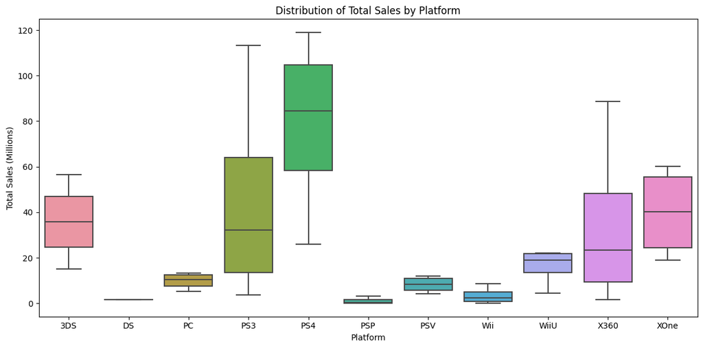

```python
# Create box plot of sales by platform
plt.figure(figsize=(12, 6))
sns.boxplot(data=yoy, x='platform', y='total_sales')
plt.title('Distribution of Total Sales by Platform')
plt.xlabel('Platform')
plt.ylabel('Total Sales (Millions)')
plt.tight_layout()
plt.show()
```

```python
# Calculate detailed statistics for each platform
yoy_stats = yoy.groupby('platform')['total_sales'].describe().round(2)
display(yoy_stats)
```

| platform | count | mean | std | min | 25% | 50% | 75% | max |
| --- | --- | --- | --- | --- | --- | --- | --- | --- |
| 3DS | 4.0 | 35.81 | 18.13 | 15.14 | 24.62 | 35.77 | 46.96 | 56.57 |
| DS | 1.0 | 1.54 | NaN | 1.54 | 1.54 | 1.54 | 1.54 | 1.54 |
| PC | 4.0 | 9.86 | 3.70 | 5.25 | 7.70 | 10.45 | 12.60 | 13.28 |
| PS3 | 4.0 | 45.36 | 48.90 | 3.60 | 13.52 | 32.29 | 64.13 | 113.25 |
| PS4 | 4.0 | 78.54 | 40.57 | 25.99 | 58.44 | 84.62 | 104.72 | 118.90 |
| PSP | 3.0 | 1.17 | 1.71 | 0.12 | 0.18 | 0.24 | 1.69 | 3.14 |
| PSV | 4.0 | 8.25 | 3.60 | 4.25 | 5.75 | 8.42 | 10.92 | 11.90 |
| Wii | 4.0 | 3.42 | 3.77 | 0.18 | 0.90 | 2.44 | 4.96 | 8.59 |
| WiiU | 4.0 | 16.16 | 8.13 | 4.60 | 13.41 | 19.00 | 21.74 | 22.03 |
| X360 | 4.0 | 34.20 | 38.82 | 1.52 | 9.35 | 23.35 | 48.20 | 88.58 |
| XOne | 4.0 | 39.83 | 20.31 | 18.96 | 24.35 | 40.11 | 55.59 | 60.14 |

## 3.6 Review Score Impact Analysis

Select a popular platform and analyze how reviews affect sales:

```python
# Choose a popular platform based on your previous analysis
```

PS4

```python
# Create scatter plots for both critic and user scores
ps4 = df[(df['platform'] == 'PS4') & (df['year_of_release'] >= 2013) & (df['missing_critic'] == 0) & (df['missing_user'] == 0)]
```

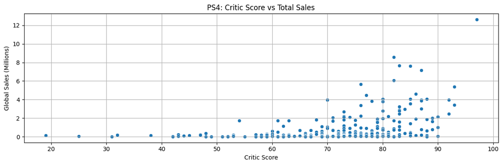

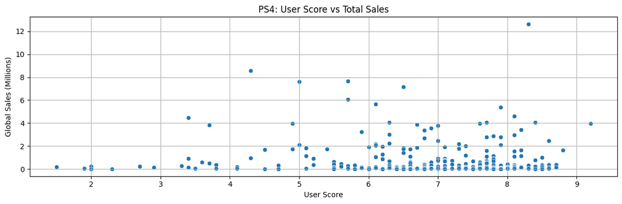

|  | critic_score | user_score | total_sales |
| --- | --- | --- | --- |
| critic_score | 1.000000 | 0.557654 | 0.405895 |
| user_score | 0.557654 | 1.000000 | -0.033625 |
| total_sales | 0.405895 | -0.033625 | 1.000000 |

```python
# Critic scores
plt.figure(figsize=(12, 4))
sns.scatterplot(data=ps4, x='critic_score', y='total_sales')
plt.title('PS4: Critic Score vs Total Sales')
plt.xlabel('Critic Score')
plt.ylabel('Global Sales (Millions)')
plt.grid(True)
plt.tight_layout()
plt.show()

# User scores
plt.figure(figsize=(12,4))
sns.scatterplot(data=ps4, x='user_score', y='total_sales')
plt.title('PS4: User Score vs Total Sales')
plt.xlabel('User Score')
plt.ylabel('Global Sales (Millions)')
plt.grid(True)
plt.tight_layout()
plt.show()

# Calculate correlations
ps4[['critic_score', 'user_score', 'total_sales']].corr()
```

There is a significant positive correlation between 'critic_score' and 'user_score'. There is a significant positive correlation between 'critic_score' and 'total_sales'.

## 3.7 Cross-Platform Comparison

Compare sales performance of games across different platforms:

```python
# Find games released on multiple platforms
multi_platform_games = df.groupby('name')['platform'].nunique().reset_index()
multi_platform_games = multi_platform_games[multi_platform_games['platform'] > 1]
multi_platform_games.columns = ['name', 'platform_count']
multi_platform_games
```

|  | name | platform_count |
| --- | --- | --- |
| 2 | Frozen: Olaf's Quest | 2 |
| 8 | 2014 FIFA World Cup Brazil | 2 |
| 10 | 3rd Super Robot Wars Z Jigoku Hen | 2 |
| 11 | 3rd Super Robot Wars Z: Tengoku-Hen | 2 |
| 13 | 7 Days to Die | 2 |
| ... | ... | ... |
| 1253 | Zero Escape: Zero Time Dilemma | 2 |
| 1256 | ZombiU | 2 |
| 1257 | Zombie Army Trilogy | 2 |
| 1258 | Zoo Tycoon (2013) | 2 |
| 1259 | Zumba Fitness: World Party | 2 |

473 rows × 2 columns

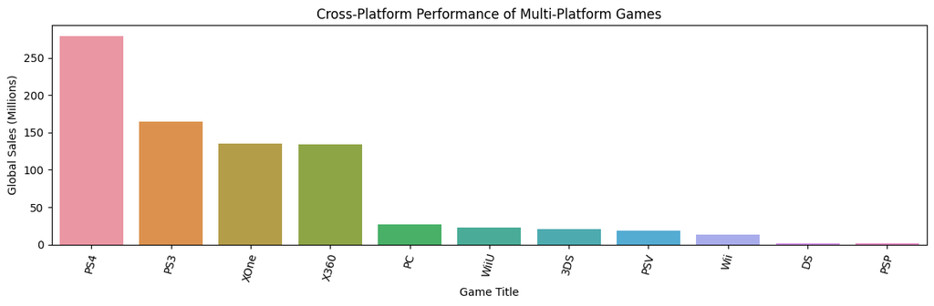

```python
# Compare sales across platforms for these games
df_joined = df.merge(multi_platform_games, on='name', how='inner')
platform_performance = (
    df_joined.groupby(['platform'])['total_sales'].sum().reset_index().sort_values(by='total_sales', ascending=False))

# Your code here to analyze and visualize cross-platform performance
plt.figure(figsize=(12, 4))
sns.barplot(data=platform_performance, x='platform', y='total_sales')
plt.xticks(rotation=75)
plt.title('Cross-Platform Performance of Multi-Platform Games')
plt.ylabel('Global Sales (Millions)')
plt.xlabel('Game Title')
plt.tight_layout()
plt.show()
```

## 3.8 Genre Analysis

Finally, let's examine the distribution of games by genre:

```python
# Analyze genre performance.
# Sort genres by total sales
genre_sales = (
    df.groupby('genre')['total_sales'].sum().reset_index().sort_values(by='total_sales', ascending=False))
genre_sales
```

|  | genre | total_sales |
| --- | --- | --- |
| 0 | Action | 321.87 |
| 8 | Shooter | 232.98 |
| 10 | Sports | 150.65 |
| 7 | Role-Playing | 145.89 |
| 3 | Misc | 62.82 |
| 4 | Platform | 42.63 |
| 6 | Racing | 39.89 |
| 2 | Fighting | 35.31 |
| 1 | Adventure | 23.64 |
| 9 | Simulation | 21.76 |
| 11 | Strategy | 10.08 |
| 5 | Puzzle | 3.17 |

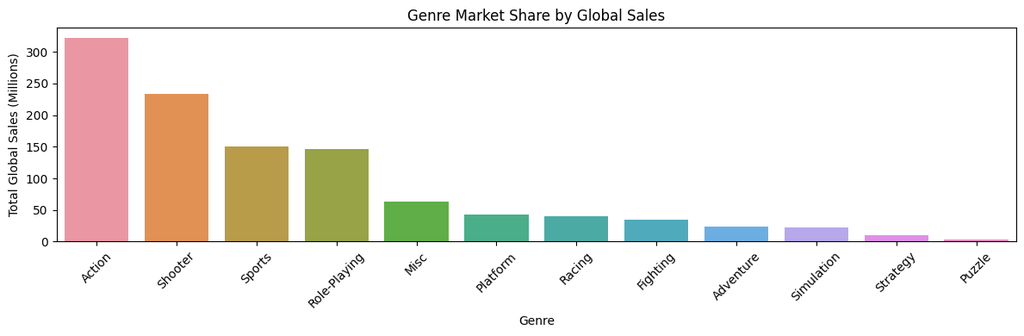

```python
# Visualize genre distribution
plt.figure(figsize=(12, 4))
sns.barplot(data=genre_sales, x='genre', y='total_sales')
plt.title('Genre Market Share by Global Sales')
plt.xlabel('Genre')
plt.ylabel('Total Global Sales (Millions)')
plt.xticks(rotation=45)
plt.tight_layout()
plt.show()
```

```python
# Calculate market share for each genre
total_sales_all = df['total_sales'].sum()
genre_sales['market_share_percent'] = (genre_sales['total_sales'] / total_sales_all) * 100
genre_sales = genre_sales.sort_values(by='market_share_percent', ascending=False)
genre_sales
```

|  | genre | total_sales | market_share_percent |
| --- | --- | --- | --- |
| 0 | Action | 321.87 | 29.510677 |
| 8 | Shooter | 232.98 | 21.360790 |
| 10 | Sports | 150.65 | 13.812357 |
| 7 | Role-Playing | 145.89 | 13.375936 |
| 3 | Misc | 62.82 | 5.759657 |
| 4 | Platform | 42.63 | 3.908535 |
| 6 | Racing | 39.89 | 3.657318 |
| 2 | Fighting | 35.31 | 3.237400 |
| 1 | Adventure | 23.64 | 2.167435 |
| 9 | Simulation | 21.76 | 1.995067 |
| 11 | Strategy | 10.08 | 0.924186 |
| 5 | Puzzle | 3.17 | 0.290642 |

### Key Questions for Genre Analysis:

- Which genres consistently perform well?
- Are there any genres showing recent growth or decline?
- How does the average performance vary across genres?

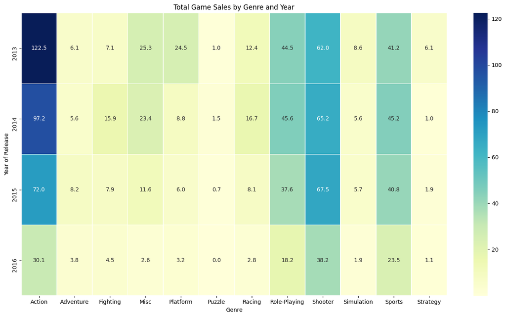

```
                 mean        std  consistency_ratio
genre
Action        80.4675  39.394548           2.042605
Shooter       58.2450  13.537037           4.302640
Sports        37.6625   9.649205           3.903171
Role-Playing  36.4725  12.692463           2.873556
Misc          15.7050  10.633816           1.476892
Platform      10.6575   9.531245           1.118165
Racing         9.9725   5.935163           1.680240
Fighting       8.8275   4.905183           1.799627
Adventure      5.9100   1.786859           3.307479
Simulation     5.4400   2.759626           1.971282
Strategy       2.5200   2.429856           1.037099
Puzzle         0.7925   0.614729           1.289186
```

```python
well = df[df['year_of_release'].notna()]
genre_trends = well.groupby(['genre', 'year_of_release'])['total_sales'].sum().reset_index()
genre_pivot = genre_trends.pivot(index='year_of_release', columns='genre', values='total_sales').fillna(0)

plt.figure(figsize=(14, 8))
sns.heatmap(genre_pivot, cmap='YlGnBu', annot=True, fmt='.1f', linewidths=0.5)
plt.title('Total Game Sales by Genre and Year')
plt.xlabel('Genre')
plt.ylabel('Year of Release')
plt.tight_layout()
plt.show()

genre_stats = genre_pivot.describe().T[['mean', 'std']]
genre_stats['consistency_ratio'] = genre_stats['mean'] / genre_stats['std']
print(genre_stats.sort_values(by='mean', ascending=False))
```

The action and shooter genre performed best followed by sports and role-playing. You can see a significant decrease in action video game sales through the years along with recent decreases for the other video game genres I have listed. To see how performance varies accross genres, I have created a metric that compares average sales to their fluctuations. For the most part average performance across genres is pretty stable, specifically shooter, sports and adventure games in that order.

# Step 4: Regional Market Analysis and User Profiles

In this section, we will analyze the gaming market characteristics across three major regions: North America (NA), Europe (EU), and Japan (JP). Our analysis will focus on platform preferences, genre popularity, and the impact of ESRB ratings in each region.

## 4.1 Regional Platform Analysis

Let's begin by examining platform performance across different regions:

```python
# Function to analyze platform performance by region
regional_sales = df.groupby('platform')[['na_sales', 'eu_sales', 'jp_sales', 'other_sales']].sum()
regional_sales['total_sales'] = regional_sales.sum(axis=1)
regional_sales.sort_values(by='total_sales', ascending=False)
```

| platform | na_sales | eu_sales | jp_sales | other_sales | total_sales |
| --- | --- | --- | --- | --- | --- |
| PS4 | 108.74 | 141.09 | 15.96 | 48.35 | 314.14 |
| PS3 | 63.50 | 67.81 | 23.35 | 26.77 | 181.43 |
| XOne | 93.12 | 51.59 | 0.34 | 14.27 | 159.32 |
| 3DS | 38.20 | 30.96 | 67.81 | 6.28 | 143.25 |
| X360 | 81.66 | 42.52 | 0.51 | 12.11 | 136.80 |
| WiiU | 29.21 | 19.85 | 10.88 | 4.69 | 64.63 |
| PC | 11.11 | 25.36 | 0.00 | 2.96 | 39.43 |
| PSV | 5.04 | 6.10 | 18.59 | 3.26 | 32.99 |
| Wii | 6.56 | 5.93 | 0.05 | 1.12 | 13.66 |
| PSP | 0.00 | 0.17 | 3.29 | 0.04 | 3.50 |
| DS | 0.57 | 0.85 | 0.00 | 0.12 | 1.54 |

```python
# Analyze each region

region_totals = df[['na_sales', 'eu_sales', 'jp_sales', 'other_sales']].sum().sort_values(ascending=False)
print(region_totals)
```

```
na_sales       437.71
eu_sales       392.23
jp_sales       140.78
other_sales    119.97
dtype: float64
```

### Cross-Regional Platform Comparison

Let's create a comparative analysis of platform performance across regions:

```python
# Create a comparative platform analysis

platform_region_sales = (
    df.groupby('platform')[['na_sales', 'eu_sales', 'jp_sales', 'other_sales']]
    .sum()
    .sort_values(by=['na_sales', 'eu_sales', 'jp_sales', 'other_sales'], ascending=False)
)

platform_region_sales.head()
```

| platform | na_sales | eu_sales | jp_sales | other_sales |
| --- | --- | --- | --- | --- |
| PS4 | 108.74 | 141.09 | 15.96 | 48.35 |
| XOne | 93.12 | 51.59 | 0.34 | 14.27 |
| X360 | 81.66 | 42.52 | 0.51 | 12.11 |
| PS3 | 63.50 | 67.81 | 23.35 | 26.77 |
| 3DS | 38.20 | 30.96 | 67.81 | 6.28 |

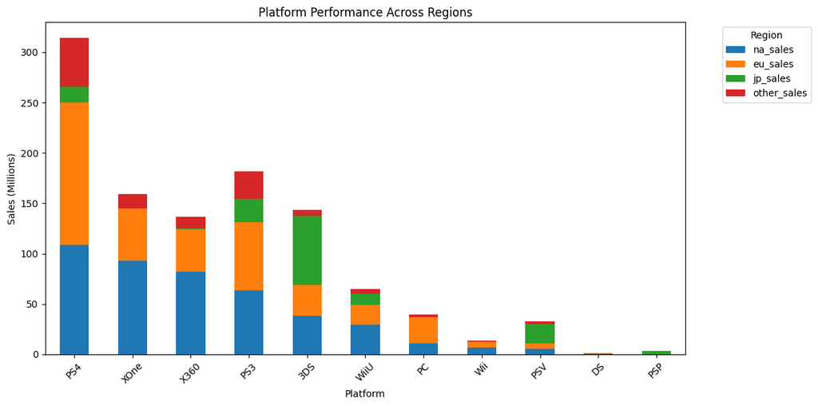

```python
# Visualize cross-regional comparison for top platforms
platform_region_sales.plot(kind='bar', stacked=True, figsize=(12, 6))

plt.title('Platform Performance Across Regions')
plt.xlabel('Platform')
plt.ylabel('Sales (Millions)')
plt.xticks(rotation=45)
plt.legend(title='Region', bbox_to_anchor=(1.05, 1), loc='upper left')
plt.tight_layout()
plt.show()
```

## 4.2 Regional Genre Analysis

Now let's examine genre preferences across regions:

```python
# Function to analyze genre performance by region
genre_region_sales = (
    df.groupby('genre')[['na_sales', 'eu_sales', 'jp_sales', 'other_sales']]
    .sum()
    .sort_values(by=['na_sales', 'eu_sales', 'jp_sales', 'other_sales'], ascending=False)
)

genre_region_sales.head()
```

| genre | na_sales | eu_sales | jp_sales | other_sales |
| --- | --- | --- | --- | --- |
| Action | 126.05 | 118.13 | 40.49 | 37.20 |
| Shooter | 109.74 | 87.86 | 6.61 | 28.77 |
| Sports | 65.27 | 60.52 | 5.41 | 19.45 |
| Role-Playing | 46.40 | 36.97 | 51.04 | 11.48 |
| Misc | 27.49 | 20.04 | 9.20 | 6.09 |

### Cross-Regional Genre Comparison

Let's compare genre preferences across regions:

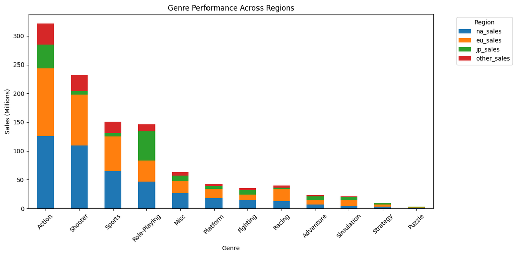

| genre | na_sales | eu_sales | jp_sales | other_sales | total_sales | market_share_pct |
| --- | --- | --- | --- | --- | --- | --- |
| Action | 126.05 | 118.13 | 40.49 | 37.20 | 321.87 | 29.510677 |
| Shooter | 109.74 | 87.86 | 6.61 | 28.77 | 232.98 | 21.360790 |
| Sports | 65.27 | 60.52 | 5.41 | 19.45 | 150.65 | 13.812357 |
| Role-Playing | 46.40 | 36.97 | 51.04 | 11.48 | 145.89 | 13.375936 |
| Misc | 27.49 | 20.04 | 9.20 | 6.09 | 62.82 | 5.759657 |
| Platform | 18.14 | 15.58 | 4.79 | 4.12 | 42.63 | 3.908535 |
| Fighting | 15.55 | 8.55 | 7.65 | 3.56 | 35.31 | 3.237400 |
| Racing | 12.96 | 20.19 | 2.30 | 4.44 | 39.89 | 3.657318 |
| Adventure | 7.14 | 8.25 | 5.82 | 2.43 | 23.64 | 2.167435 |
| Simulation | 4.86 | 10.92 | 4.52 | 1.46 | 21.76 | 1.995067 |
| Strategy | 3.28 | 4.22 | 1.77 | 0.81 | 10.08 | 0.924186 |
| Puzzle | 0.83 | 1.00 | 1.18 | 0.16 | 3.17 | 0.290642 |

```python
# Create a comparative genre analysis
genre_region_sales[['na_sales', 'eu_sales', 'jp_sales', 'other_sales']].plot(kind='bar', stacked=True, figsize=(12, 6))
plt.title('Genre Performance Across Regions')
plt.xlabel('Genre')
plt.ylabel('Sales (Millions)')
plt.xticks(rotation=45)
plt.legend(title='Region', bbox_to_anchor=(1.05, 1), loc='upper left')
plt.tight_layout()
plt.show()



genre_region_sales['total_sales'] = genre_region_sales.sum(axis=1)
genre_region_sales['market_share_pct'] = (
    genre_region_sales['total_sales'] / genre_region_sales['total_sales'].sum()) * 100
genre_region_sales
```

## 4.3 ESRB Rating Impact Analysis

Finally, let's examine how ESRB ratings affect sales in each region:

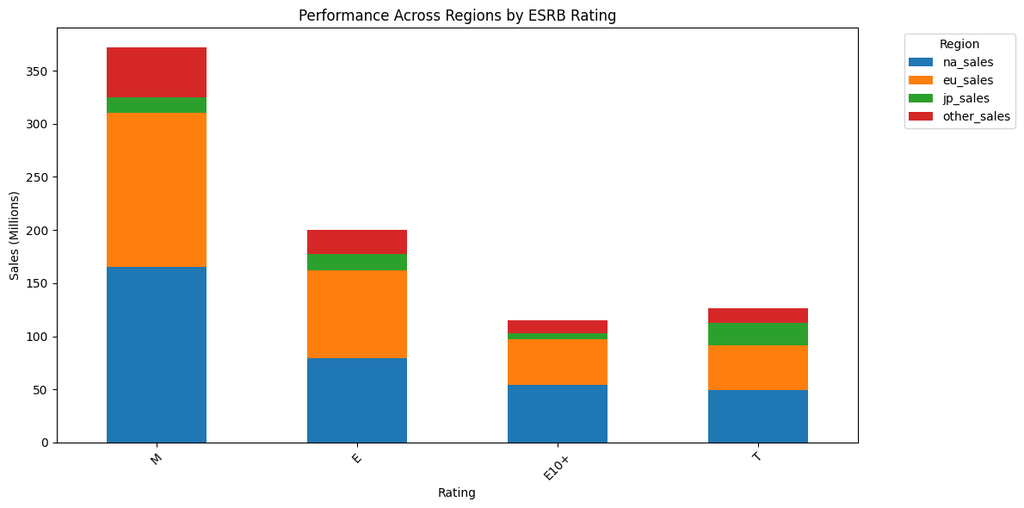

| rating | na_sales | eu_sales | jp_sales | other_sales | total_sales | market_share_pct |
| --- | --- | --- | --- | --- | --- | --- |
| M | 165.21 | 145.32 | 14.11 | 47.04 | 371.68 | 45.669349 |
| E | 79.05 | 83.36 | 15.14 | 22.61 | 200.16 | 24.594213 |
| E10+ | 54.24 | 42.69 | 5.89 | 12.57 | 115.39 | 14.178288 |
| T | 49.79 | 41.95 | 20.59 | 14.29 | 126.62 | 15.558150 |

```python
# Function to analyze ESRB rating impact
esrb_sales = (
    df.groupby('rating')[['na_sales', 'eu_sales', 'jp_sales', 'other_sales']]
    .sum()
    .sort_values(by=['na_sales', 'eu_sales', 'jp_sales', 'other_sales'], ascending=False)
)

# Analyze ESRB impact for each region

esrb_sales[['na_sales', 'eu_sales', 'jp_sales', 'other_sales']].plot(kind='bar', stacked=True, figsize=(12, 6))
plt.title('Performance Across Regions by ESRB Rating')
plt.xlabel('Rating')
plt.ylabel('Sales (Millions)')
plt.xticks(rotation=45)
plt.legend(title='Region', bbox_to_anchor=(1.05, 1), loc='upper left')
plt.tight_layout()
plt.show()


esrb_sales['total_sales'] = esrb_sales.sum(axis=1)
esrb_sales['market_share_pct'] = (esrb_sales['total_sales'] / esrb_sales['total_sales'].sum()) * 100
esrb_sales
```

How does rating affect sails in each region? We can see that games rated 'M' own the highest market share and are dominating the North American Market. Games rated 'E' follow behind in second. We can see a very small amount of games being sold with ESRB rating found in the Japanese Market. Finally, other sales of games with ESRB ratings follow the same pattern as the rest of the data (besides japanese released games with ratings) with the most sales in for games rated 'M' released in NA.

# Step 5 : Hypothesis Tests

—Average user ratings of the Xbox One and PC platforms are the same.

—Average user ratings for the Action and Sports genres are different.

Set the *alpha* threshold value yourself.

Explain:

—How you formulated the null and alternative hypotheses

—What criteria you used to test the hypotheses, and why

Null Hypothesis 1: Average user ratings of the Xbox One and PC platforms are the same. Alternative Hypothesis 1: Average user ratings of the Xbox One and PC platforms are NOT the same. The Null Hypothesis should always hold the equal statement. We will set alpha value to 0.05 so we can balance avoiding false positives with finding a correlation. This value will allow us to be confident in our findings without being to conservative.

```python
# Test the hypotheses
df_platforms = df[df['platform'].isin(['XOne', 'PC'])][['platform', 'user_score']].dropna()
xbox_ratings = df_platforms[df_platforms['platform'] == 'XOne']['user_score']
pc_ratings = df_platforms[df_platforms['platform'] == 'PC']['user_score']
alpha=0.05
results = st.ttest_ind(xbox_ratings, pc_ratings, equal_var=False)

print('p-value:', results.pvalue)
if (results.pvalue < alpha):
    print("We reject the null hypothesis")
else:
    print("We can't reject the null hypothesis")
```

```
p-value: 0.14759594013430463
We can't reject the null hypothesis
```

Null Hypothesis 2: Average user ratings for the Action and Sports genres are the same. Alternative Hypothesis 2: Average user ratings for the Action and Sports genres are different The Null Hypothesis should always hold the equal statement. We will set alpha value to 0.05 so we can balance avoiding false positives with finding a correlation. This value will allow us to be confident in our findings without being to conservative.

```python
# Test the hypotheses
df_genres = df[df['genre'].isin(['Action', 'Sports'])][['genre', 'user_score']].dropna()
action = df_genres[df_genres['genre'] == 'Action']['user_score']
sports = df_genres[df_genres['genre'] == 'Sports']['user_score']
alpha=0.05
results = st.ttest_ind(action, sports, equal_var=False)

print('p-value:', results.pvalue)
if (results.pvalue < alpha):
    print("We reject the null hypothesis")
else:
    print("We can't reject the null hypothesis")
```

```
p-value: 1.4460039700704315e-20
We reject the null hypothesis
```

# Conclusion

WHAT DETERMINES A GAMES SUCCESS